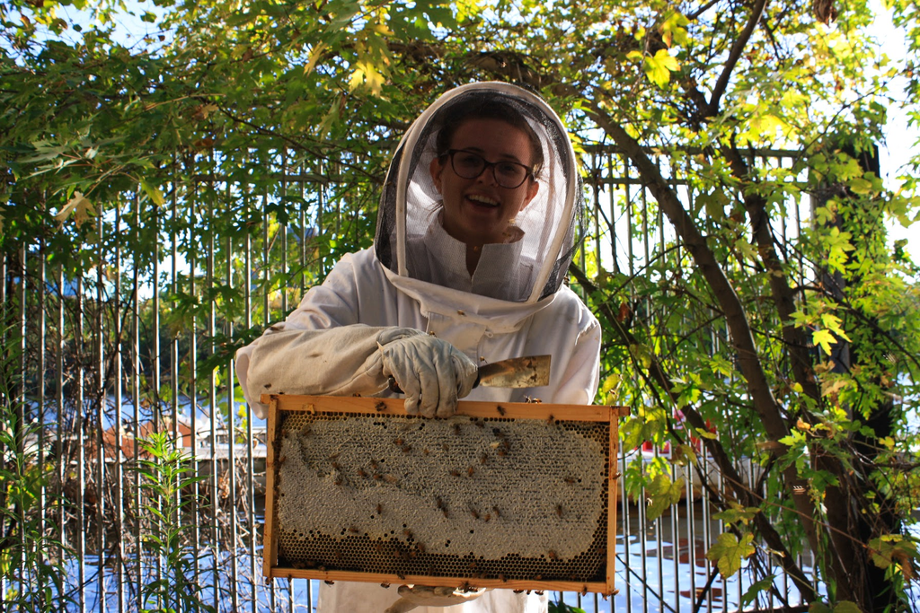

# Allie Cole

Hello! My name is Allie Cole (she/her) and I am a marine scientist who loves to dive and explore the oceans. I graduated from Boston University in 2021 with a bachelor’s degree in Marine Science. My previous research is in larval fish identification from the Central Pacific, exploring how their distributions are changing with climate patterns. For this research I led a team of up to eight students and worked with multiple international collaborators. I was the recipient of the Lara Vincent Undergraduate Research Award for this work. You can see a summary video of the data collection [here](https://www.bu.edu/articles/2019/phoenix-islands-fieldwork-vlog/) Analysis of this data led me to UCSB’s Bren School of Environmental Sciences and Management, where I am currently working towards a Masters in Environmental Data Science. I am interested in bridging the gap between research and data analysis, making data more open and accessible. Eventually I would like to be asking questions within marine ecology and using the knowledge gained in my masters program to share the answers I find.